# Reproducible Research: Peer Assessment 1

Set some global options for processing the R markdown file

```r
library(knitr, quietly=TRUE)
opts_chunk$set(echo=TRUE, message=FALSE, warning=FALSE, error=FALSE, results="hide")
```

## Loading and preprocessing the data

Download zip-file from course repository and import included dataset into activity object. Results are cached to avoid extensive downloading of the datafile.

```r
suppressPackageStartupMessages(library(tidyverse))
temp <- tempfile()
download.file("https://d396qusza40orc.cloudfront.net/repdata%2Fdata%2Factivity.zip",temp)
activity <- read_csv(unz(temp, "activity.csv"),
             quote="\"",
             col_types = cols(date=col_date(format="%Y-%m-%d")),
             na = "NA")
unlink(temp)
```

## What is mean total number of steps taken per day?

To calculate the mean and median of the steps taken per day and to produce a histogram of these values first the steps are summed up by day ignoring the NA values. From the resulting daily summaries the mean and median is calculated.

```r
suppressPackageStartupMessages(library(tidyverse))
activity_by_day <- activity %>%
    group_by(date) %>%
    summarize(StepsSum = sum(steps, na.rm=TRUE))

meanSteps <- round(mean(activity_by_day$StepsSum),0)
medianSteps <- round(median(activity_by_day$StepsSum),0)
```

The (rounded) mean and median values for the steps taken per day are 9354 and 10395, respectively. A histogram including markes of the mean and median is shown below.

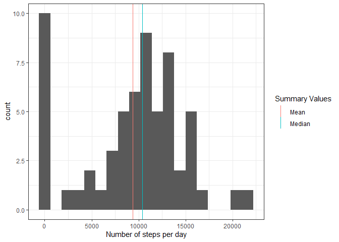

```r
p1 <- ggplot() +
    geom_histogram(data = activity_by_day, aes(x=StepsSum), binwidth=1200) +
    geom_vline(aes(xintercept=meanSteps, colour="Mean")) +
    geom_vline(aes(xintercept=medianSteps, colour="Median")) +
    scale_x_continuous("Number of steps per day") +
    scale_colour_discrete("Summary Values") +
    theme_bw()

print(p1)
```

## What is the average daily activity pattern?

To plot the average daily activity pattern the dataset is first grouped by interval calculating the average numbers of steps. Subesquently the interval containing the maximum number of steps is identified.

```r
suppressPackageStartupMessages(library(tidyverse))

activity_by_interval <- activity %>%
    group_by(interval) %>%
    summarize(MeanSteps = mean(steps, na.rm=TRUE))

max_activity_by_interval <- activity_by_interval %>%
    arrange(MeanSteps) %>%
    dplyr::top_n(1)

maxInterval <- max_activity_by_interval$interval
```

A plot of the average number of steps per interval is shown below highlighting interval 835 containing the maximum average step count.

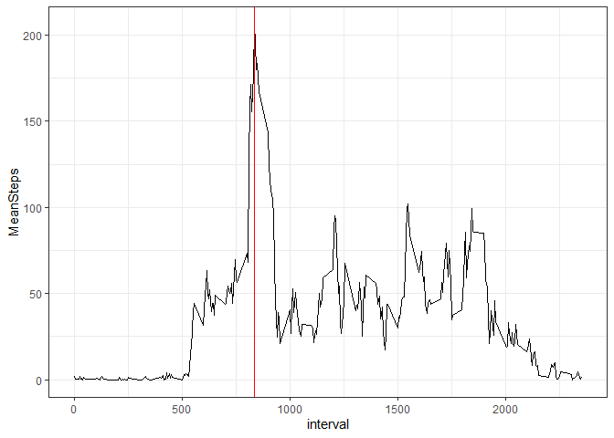

```r
p2 <- ggplot() +
    geom_line(data = activity_by_interval, aes(x=interval, y=MeanSteps), group=1) +
    geom_vline(xintercept=maxInterval, colour="red") +
    theme_bw()

print(p2)
```

## Imputing missing values

Some donwstream analyses might be affected by the missing (“NA”) values for some day/interval combinations in the dataset. In order to improve this the missing values are replaced by the mean of the respective interval across the whole dataset.

```r
suppressPackageStartupMessages(library(tidyverse))

missingCount <- sum(is.na(activity$steps))
missingPercent <- round(missingCount/(missingCount+sum(!is.na(activity$steps)))*100,0)

activity_imputed <- activity %>%
    left_join(activity_by_interval) %>%
    mutate(steps_imputed = coalesce(steps,MeanSteps)) %>%
    select(steps_imputed, date, interval) %>%
    rename(steps = steps_imputed)

activity_by_day_imputed <- activity_imputed %>%
    group_by(date) %>%
    summarize(StepsSum = sum(steps, na.rm=TRUE))

meanStepsImputed <- round(mean(activity_by_day_imputed$StepsSum),0)
medianStepsImputed <- round(median(activity_by_day_imputed$StepsSum),0)
```

In total the dataset included 2304 NA values for the steps taken which corresponds to 13% of the whole dataset. Using the imputation method described above the mean changes to 10766 (from 9354) while the median changes to 10766 (from 10395).

Below the histogram created from the imputed dataset is shown together with the highlighted mean and median values. Note that for the imputed dataset mean and median values are identical!

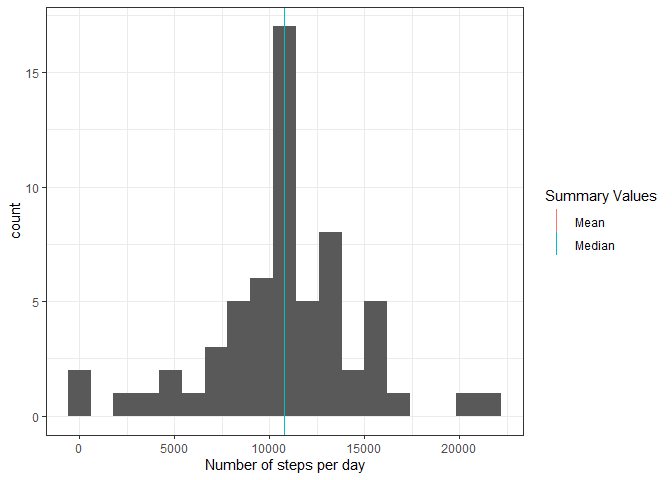

```r
p3 <- ggplot() +
    geom_histogram(data = activity_by_day_imputed, aes(x=StepsSum), binwidth=1200) +
    geom_vline(aes(xintercept=meanStepsImputed, colour="Mean")) +
    geom_vline(aes(xintercept=medianStepsImputed, colour="Median")) +
    scale_x_continuous("Number of steps per day") +
    scale_colour_discrete("Summary Values") +
    theme_bw()

print(p3)
```

## Are there differences in activity patterns between weekdays and weekends?

For the analysis of different patterns first an additional variable “day” is created containing the values “Weekday” or “Weekend” calculated from the “date” column. Then a panel plot is created showing the average number of steps per interval for weekdays and weekends respectively. This plot shows that while the overall pattern looks similar the large spike around interval 800 is much more present on weekdays than on the weekends.

```r
suppressPackageStartupMessages(library(tidyverse))
suppressPackageStartupMessages(library(timeDate))

activity_by_interval_and_day  <- activity_imputed %>%
    mutate(day = case_when(isWeekend(date) ~ "Weekend",
                   !isWeekend(date) ~ "Weekday")) %>%
    group_by(interval, day) %>%
    summarize(MeanSteps = mean(steps, na.rm=TRUE))
```

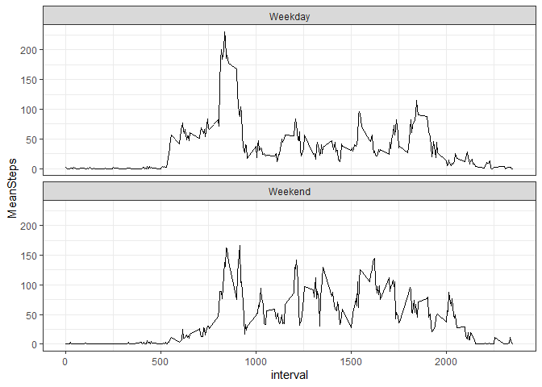

```r
p4 <- ggplot() +
    geom_line(data = activity_by_interval_and_day, aes(x=interval, y=MeanSteps, group=day)) +
    facet_wrap(~day, ncol=1) +
    theme_bw()

print(p4)
```